# Lab 05

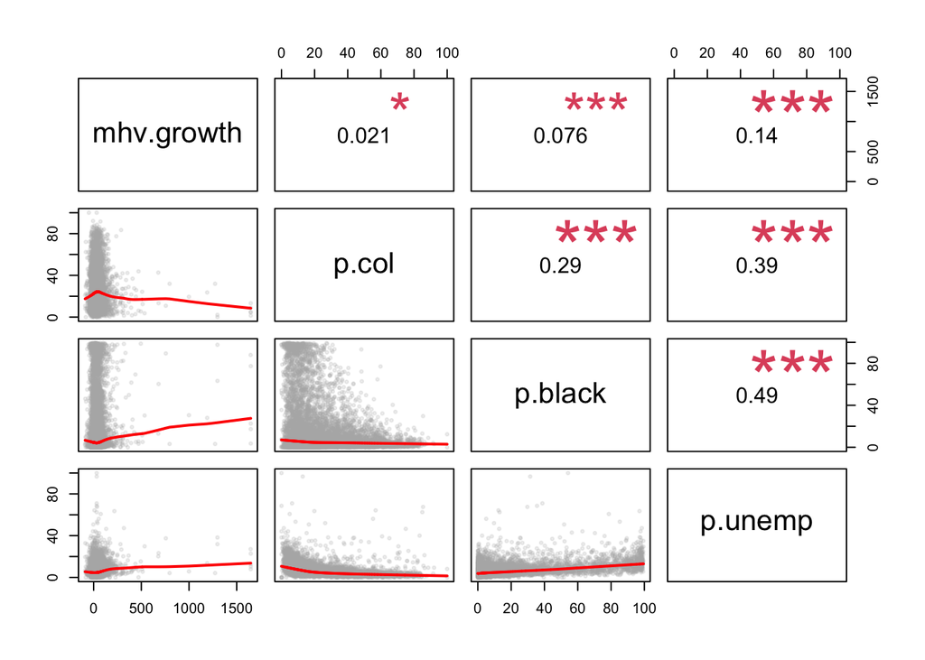

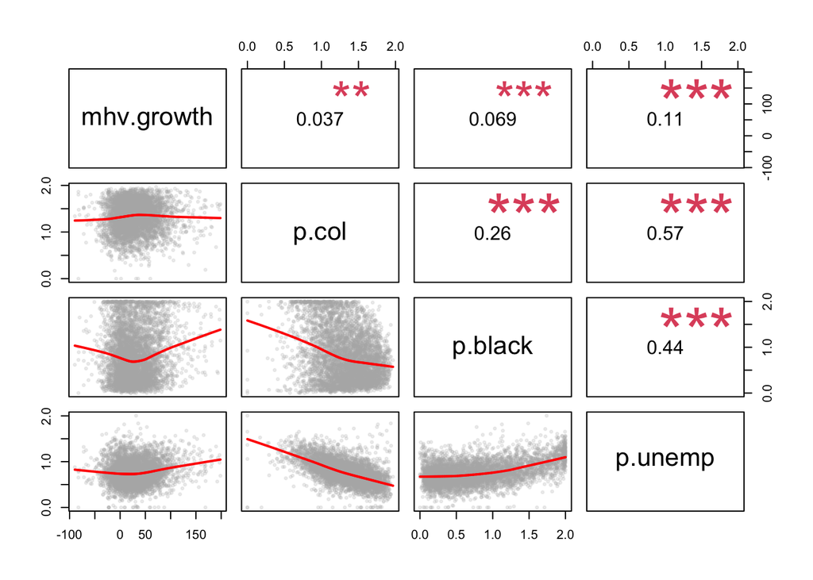

[output not shown]

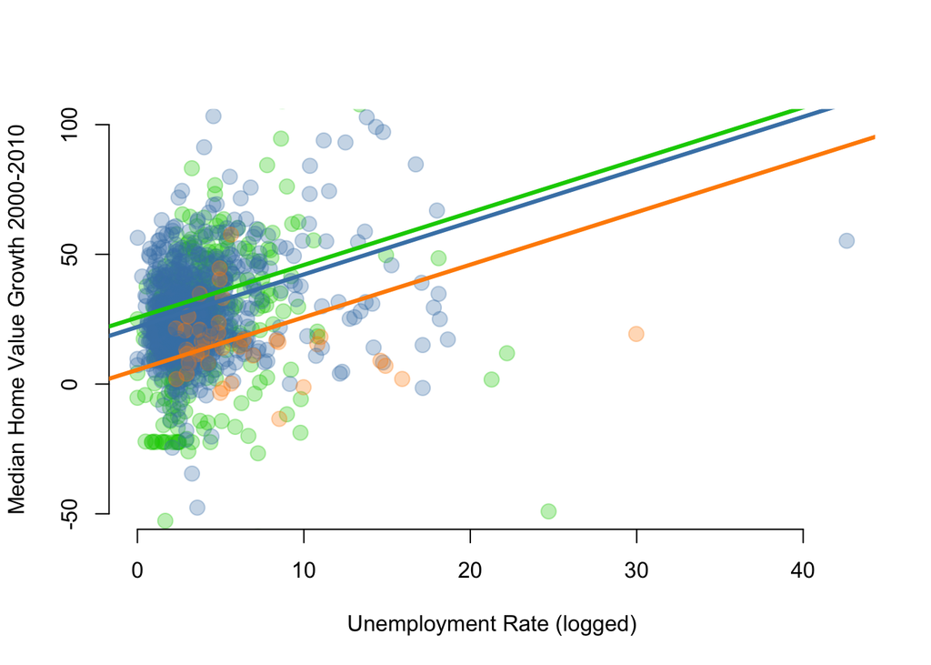

[output not shown]

[output cut: 60 more lines]

[output not shown]

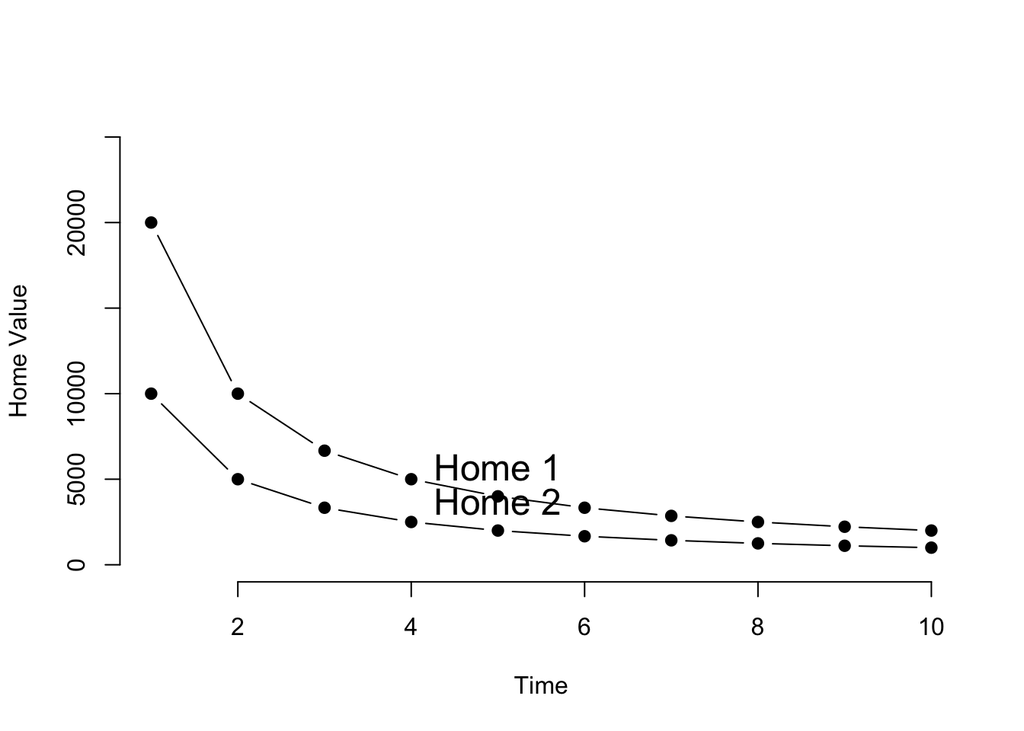

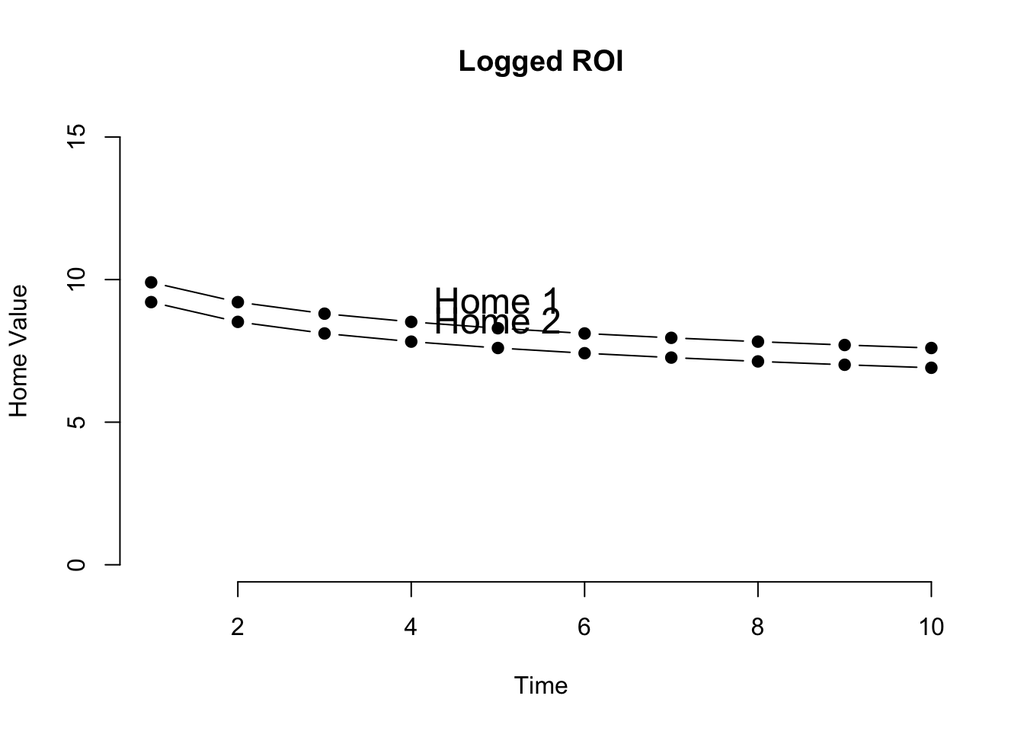

[output not shown]

### Descriptive Statistics

Table continues below

| tractid | mhmval00 | mhmval12 | hinc00 | hinc12 | hu10 | own10 |
| --- | --- | --- | --- | --- | --- | --- |
| fips-01-001-020100 | 76600 | 121500 | 36685 | 56500 | 752 | 536 |

| rent10 | hu00 | vac00 | own00 | rent00 | h30old00 | empclf00 | clf00 |
| --- | --- | --- | --- | --- | --- | --- | --- |
| 157 | 769 | 93 | 518 | 158 | 225 | 826 | 872 |

**Home values- All data**

| Statistic | Min | Pctl(25) | Median | Mean | Pctl(75) | Max |
| --- | --- | --- | --- | --- | --- | --- |
| mhmval00 | 0 | 81,600 | 119,900 | 144,738 | 173,894 | 1,000,001 |
| mhmval12 | 9,999 | 123,200 | 193,200 | 246,570 | 312,000 | 1,000,001 |
| hinc00 | 2,499 | 33,000 | 43,825 | 47,657 | 58,036 | 200,001 |
| hinc12 | 2,499 | 39,226 | 54,204 | 59,607 | 73,698 | 250,001 |
| hu10 | 0 | 1,238 | 1,695 | 1,798 | 2,253 | 14,754 |
| own10 | 0 | 567 | 957 | 1,033 | 1,404 | 9,184 |
| rent10 | 0 | 254 | 471 | 589 | 792 | 8,281 |
| hu00 | 0 | 1,102 | 1,519 | 1,570 | 1,999 | 11,522 |
| vac00 | 0 | 40 | 75 | 115 | 133 | 5,252 |
| own00 | 0 | 542 | 902 | 939 | 1,289 | 4,911 |
| rent00 | 0 | 195 | 398 | 516 | 712 | 8,544 |
| h30old00 | 0 | 297 | 700 | 770 | 1,125 | 8,707 |
| empclf00 | 0 | 1,205 | 1,756 | 1,820 | 2,373 | 10,334 |
| clf00 | 0 | 1,302 | 1,865 | 1,930 | 2,502 | 11,251 |
| unemp00 | 0 | 51 | 87 | 110 | 140 | 6,405 |
| prof00 | 0 | 299 | 539 | 637 | 873 | 6,610 |
| empclf12 | 0 | 1,304.2 | 1,901 | 2,019 | 2,592 | 15,380 |
| clf12 | 0 | 1,445 | 2,071 | 2,197 | 2,806 | 16,489 |
| unemp12 | 0 | 110 | 179 | 207 | 273 | 2,132 |
| prof12 | 0 | 343 | 628 | 750 | 1,026 | 9,516 |
| dpov00 | 0 | 2,671 | 3,718 | 3,804 | 4,871 | 23,892 |
| npov00 | 0 | 149 | 304 | 452 | 601 | 5,515 |
| dpov12 | 0 | 2,849 | 3,999 | 4,231 | 5,339 | 34,249 |
| npov12 | 0 | 220 | 449 | 608 | 832 | 9,404 |
| ag25up00 | 0 | 1,763 | 2,451 | 2,520 | 3,224 | 17,974 |
| hs00 | 0 | 665 | 1,071 | 1,155 | 1,552 | 8,909 |
| col00 | 0 | 243 | 492 | 665 | 923 | 9,313 |
| ag25up12 | 0 | 1,934 | 2,706.5 | 2,849 | 3,597 | 21,414 |
| hs12 | 0 | 639 | 1,043 | 1,153 | 1,542 | 10,477 |
| col12 | 0 | 328 | 668 | 873 | 1,213 | 13,250 |
| pop00.x | 0 | 2,751 | 3,802 | 3,901 | 4,976 | 36,206 |
| nhwht00 | 0 | 1,308 | 2,514 | 2,591 | 3,713 | 20,619 |
| nhblk00 | 0 | 41 | 141 | 522 | 527 | 14,039 |
| hisp00 | 0 | 55 | 153 | 547 | 533 | 13,391 |
| asian00 | 0 | 22 | 65 | 189 | 183 | 9,491 |
| pop10 | 0 | 2,941 | 4,080 | 4,321 | 5,419 | 37,452 |
| nhwht10 | 0 | 1,206 | 2,434 | 2,621 | 3,736 | 26,244 |
| nhblk10 | 0 | 72 | 214 | 597 | 699 | 15,910 |
| hisp10 | 0 | 111 | 296 | 781 | 888 | 15,420 |
| asian10 | 0 | 36 | 103 | 273 | 281 | 11,234 |
| mar00 | 0 | 1,039 | 1,571 | 1,639 | 2,164 | 12,555 |
| flabf00 | 0 | 604 | 871 | 904 | 1,174 | 6,339 |
| p.white | 0 | 47 | 78 | 67 | 91 | 100 |
| p.black | 0 | 1 | 4 | 14 | 14 | 100 |
| p.hisp | 0 | 2 | 4 | 13 | 15 | 100 |
| p.asian | 0 | 1 | 2 | 5 | 5 | 95 |
| p.hs | 0 | 67 | 72 | 72 | 77 | 100 |
| p.col | 0 | 12 | 21 | 26 | 36 | 100 |
| p.prof | 0 | 23 | 31 | 34 | 43 | 100 |
| p.unemp | 0 | 3 | 5 | 6 | 8 | 100 |
| p.vacant | 0 | 3 | 5 | 7 | 9 | 100 |
| pov.rate | 0 | 4 | 9 | 12 | 17 | 100 |
| p.mar | 0 | 35 | 43 | 42 | 50 | 133 |
| p.flabf00 | 0 | 47 | 49 | Inf | 52 | Inf |
| mhv.00 | 11,167 | 105,661 | 154,903 | 187,129 | 224,337 | 1,288,551 |
| mhv.10 | 9,999 | 123,200 | 193,200 | 246,570 | 312,000 | 1,000,001 |
| mhv.change | -1,228,651 | 7,187 | 36,268 | 60,047 | 94,881 | 1,000,001 |
| mhv.growth | -97 | 6 | 25 | 33 | 50 | 6,059 |
| id2 | 1,001,020,100 | 12,086,010,232.0 | 26,163,574,251 | 27,253,585,612 | 40,143,007,102.0 | 56,025,001,800 |

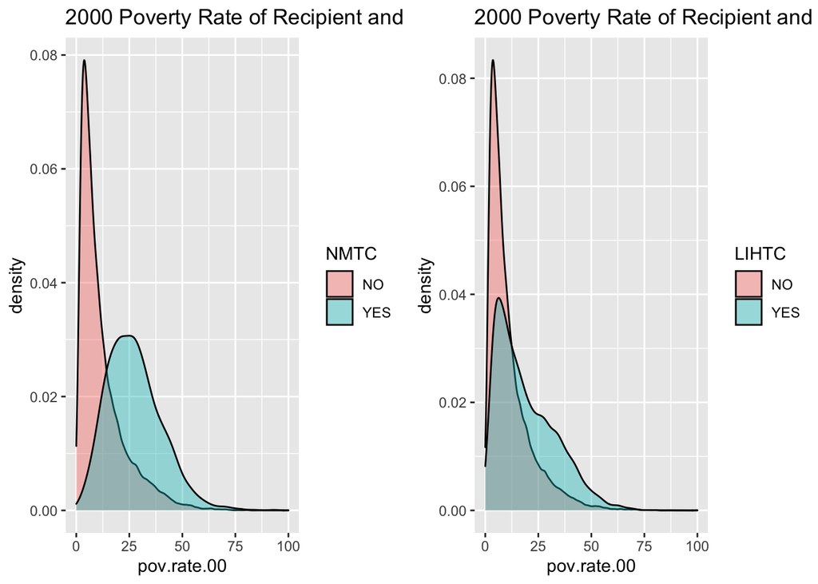

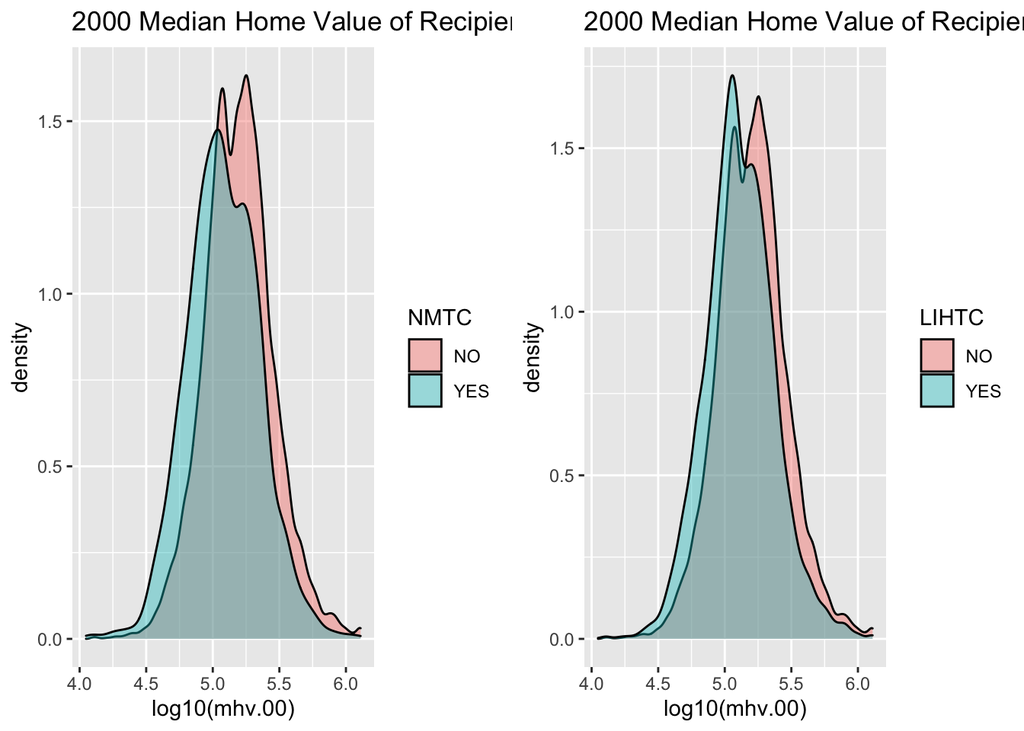

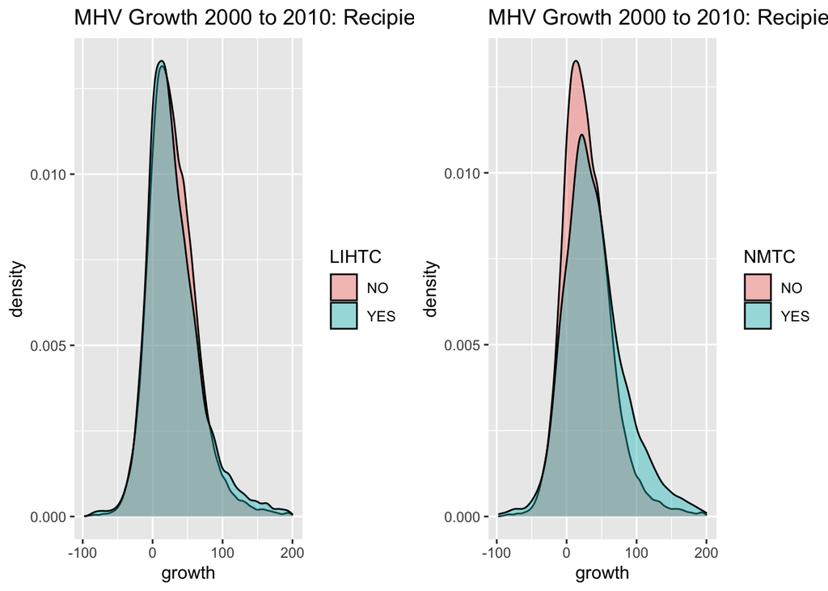

```
## [1] 200
```

### **Difference-in-Difference Model**

#### The difference-in-difference estimate seems like the most robust option since it allows for pre-treatment differences as long as the parallel lines assumption is met. That is to say, the rates of growth for the treated and untreated tracts were similar in the period 1990 to 2000. Which is another way of saying we believe that C2-C1 is a good approximation of what the home value change would have been without the program.

### NMTC Analysis

|  | Estimate | Std. Error | t value | Pr(>\|t\|) |
| --- | --- | --- | --- | --- |
| **(Intercept)** | 10.48 | 0.009367 | 1119 | 0 |
| **PercentCollegeGrad** | 0.5129 | 0.002166 | 236.8 | 0 |
| **PercentUnemployed** | 0.02875 | 0.002605 | 11.04 | 2.626e-28 |
| **PercentBlackPopulation** | -0.07229 | 0.0009466 | -76.36 | 0 |
| **treat** | 0.07153 | 0.01201 | 5.956 | 2.587e-09 |
| **post** | 0.1545 | 0.003307 | 46.73 | 0 |
| **treat:post** | 0.01779 | 0.01684 | 1.056 | 0.2908 |

Fitting linear model: y ~ PercentCollegeGrad + PercentUnemployed + PercentBlackPopulation + treat + post + treat * post

| Observations | Residual Std. Error | $R^2$ | Adjusted $R^2$ |
| --- | --- | --- | --- |
| 117616 | 0.4783 | 0.4568 | 0.4568 |

| Length | Class | Mode |
| --- | --- | --- |
| 0 | NULL | NULL |

**NMTC Treatment**

|  | *Dependent variable:* |
| --- | --- |
|  | Log Median Home Value |
| Percent College Grads | 0.51*** |
|  | (0.002) |
| Percent Unemployed | 0.03*** |
|  | (0.003) |
| Percent Black Population | -0.07*** |
|  | (0.001) |
| treat | 0.07*** |
|  | (0.01) |
| post | 0.15*** |
|  | (0.003) |
| treat:post | 0.02 |
|  | (0.02) |
| Constant | 10.48*** |
|  | (0.01) |
| Observations | 117,616 |
| R<sup>2</sup> | 0.46 |
| Adjusted R<sup>2</sup> | 0.46 |
| Residual Std. Error | 0.48 (df = 117609) |
| F Statistic | 16,486.30*** (df = 6; 117609) |
| *Note:* | p<0.1; p<0.05; p<0.01 |

### LIHTC Analysis

|  | Estimate | Std. Error | t value | Pr(>\|t\|) |
| --- | --- | --- | --- | --- |
| **(Intercept)** | 10.48 | 0.009396 | 1115 | 0 |
| **PercentCollegeGrad** | 0.5127 | 0.002171 | 236.2 | 0 |
| **PercentUnemployed** | 0.02995 | 0.002603 | 11.51 | 1.264e-30 |
| **PercentBlackPopulation** | -0.07184 | 0.0009499 | -75.63 | 0 |
| **treat** | 0.01631 | 0.005788 | 2.817 | 0.004845 |
| **post** | 0.156 | 0.003468 | 44.96 | 0 |
| **treat:post** | -0.01271 | 0.008082 | -1.572 | 0.1159 |

Fitting linear model: y ~ PercentCollegeGrad + PercentUnemployed + PercentBlackPopulation + treat + post + treat * post

| Observations | Residual Std. Error | $R^2$ | Adjusted $R^2$ |
| --- | --- | --- | --- |
| 117616 | 0.4785 | 0.4565 | 0.4564 |

**LIHTC Treatment**

|  | *Dependent variable:* |
| --- | --- |
|  | Log Median Home Value |
| Percent College Grads | 0.51*** |
|  | (0.002) |
| Percent Unemployed | 0.03*** |
|  | (0.003) |
| Percent Black Population | -0.07*** |
|  | (0.001) |
| treat | 0.02*** |
|  | (0.01) |
| post | 0.16*** |
|  | (0.003) |
| treat:post | -0.01 |
|  | (0.01) |
| Constant | 10.48*** |
|  | (0.01) |
| Observations | 117,616 |
| R<sup>2</sup> | 0.46 |
| Adjusted R<sup>2</sup> | 0.46 |
| Residual Std. Error | 0.48 (df = 117609) |
| F Statistic | 16,461.12*** (df = 6; 117609) |
| *Note:* | p<0.1; p<0.05; p<0.01 |

### Parallel Lines Test

#### NMTC Regression Summary

|  | Estimate | Std. Error | t value | Pr(>\|t\|) |
| --- | --- | --- | --- | --- |
| **(Intercept)** | 11.96 | 0.002666 | 4487 | 0 |
| **treat** | -0.2639 | 0.01584 | -16.66 | 2.977e-62 |
| **post** | 0.2295 | 0.00377 | 60.89 | 0 |
| **treat:post** | 0.09611 | 0.0224 | 4.291 | 1.781e-05 |

Fitting linear model: y ~ treat + post + treat * post

| Observations | Residual Std. Error | $R^2$ | Adjusted $R^2$ |
| --- | --- | --- | --- |
| 118132 | 0.6386 | 0.0351 | 0.03507 |

#### LIHTC Regression Summary

|  | Estimate | Std. Error | t value | Pr(>\|t\|) |
| --- | --- | --- | --- | --- |
| **(Intercept)** | 11.98 | 0.002818 | 4252 | 0 |
| **treat** | -0.2074 | 0.007578 | -27.37 | 2.052e-164 |
| **post** | 0.2315 | 0.003985 | 58.08 | 0 |
| **treat:post** | 0.005895 | 0.01072 | 0.55 | 0.5823 |

Fitting linear model: y ~ treat + post + treat * post

| Observations | Residual Std. Error | $R^2$ | Adjusted $R^2$ |
| --- | --- | --- | --- |
| 118132 | 0.6357 | 0.0437 | 0.04368 |

**NMTC and LITHC Comparison**

|  | *Dependent variable:* |  |
| --- | --- | --- |
|  | Log Median Home Value |  |
|  | NMTC | LIHTC |
|  | (1) | (2) |
| treat | -0.26*** | -0.21*** |
|  | (0.02) | (0.01) |
| post | 0.23*** | 0.23*** |
|  | (0.004) | (0.004) |
| treat:post | 0.10*** | 0.01 |
|  | (0.02) | (0.01) |
| Constant | 11.96*** | 11.98*** |
|  | (0.003) | (0.003) |
| Observations | 118,132 | 118,132 |
| R<sup>2</sup> | 0.04 | 0.04 |
| Adjusted R<sup>2</sup> | 0.04 | 0.04 |
| Residual Std. Error (df = 118128) | 0.64 | 0.64 |
| F Statistic (df = 3; 118128) | 1,432.34*** | 1,799.55*** |
| *Note:* | p<0.1; p<0.05; p<0.01 |  |

### Home value test

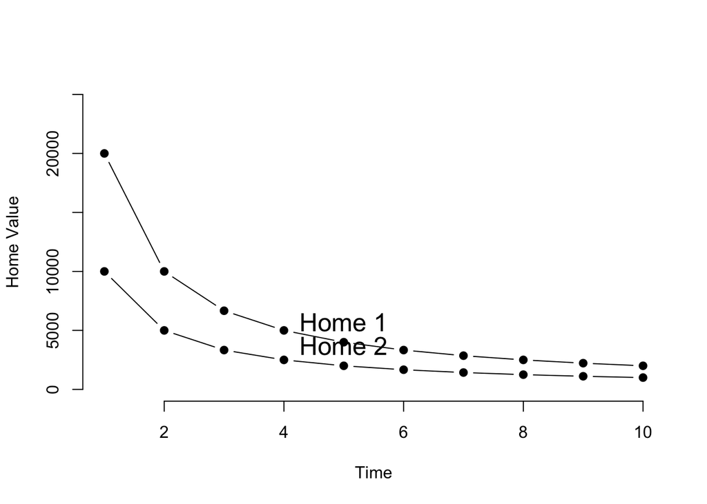

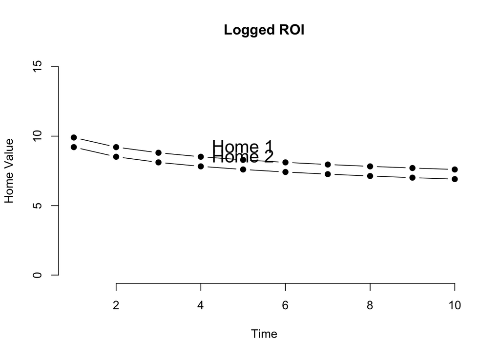

| time | value | log.value |
| --- | --- | --- |
| 1 | 20000 | 9.903 |
| 2 | 10000 | 9.21 |
| 3 | 6667 | 8.805 |
| 4 | 5000 | 8.517 |
| 5 | 4000 | 8.294 |
| 6 | 3333 | 8.112 |
| 7 | 2857 | 7.958 |
| 8 | 2500 | 7.824 |
| 9 | 2222 | 7.706 |
| 10 | 2000 | 7.601 |